# GAM of LAI anomalies from bushfires

Sami Rifai

7/9/2021

```r
pacman::p_load(tidyverse, data.table, mgcv)
```

## Load data

```r
fits <- arrow::read_parquet("../data_general/proc_data_Oz_fire_recovery/slai-1mo_logisticGrowthModel_recoveryTrajectoryfits_1burn_2001-2014fires_2021-07-08 16:10:12.parquet")
```

Making a factor variable from the month of burn. This is important for mgcv where random effects have to be specified as factors.

```r
fits[,fire_month := factor(month(date_fire1))]
```

## Plot the nonlinear terms

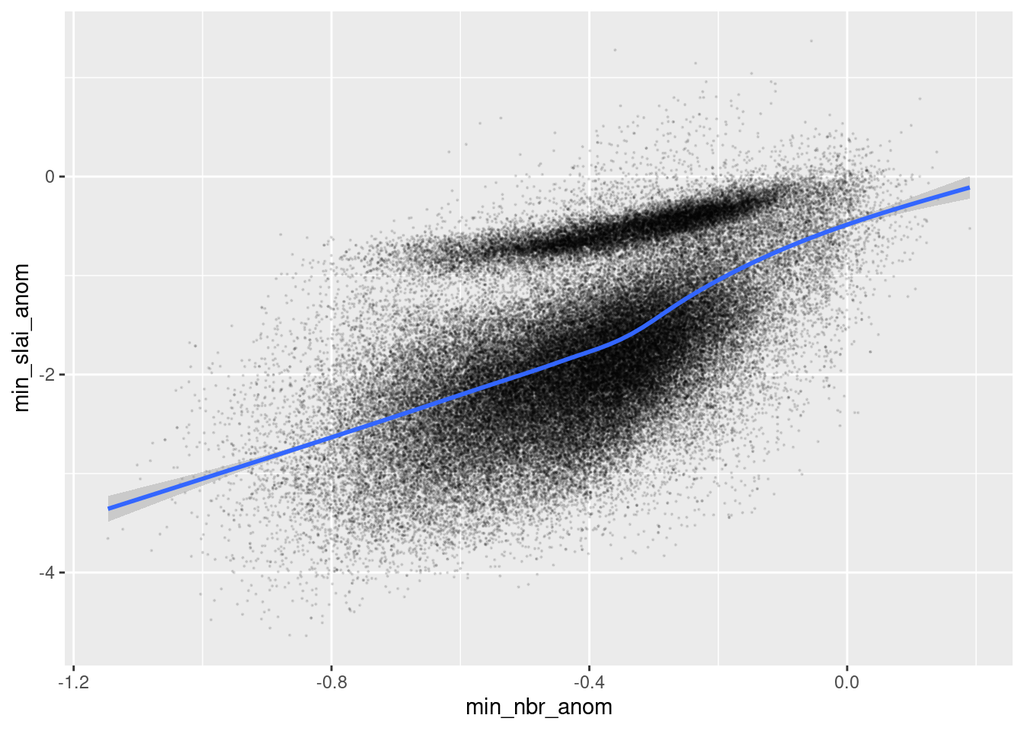

```r
fits[sample(.N,1e5)] %>%
  ggplot(data=.,aes(min_nbr_anom, min_slai_anom))+
  geom_point(size=0.1,
    alpha=0.1)+
  geom_smooth() # default gam smooth
```

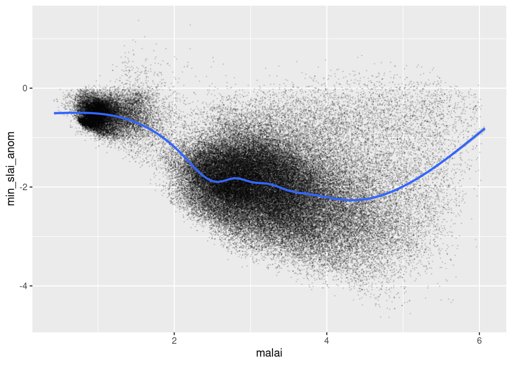

```r
fits[sample(.N,1e5)] %>%
  ggplot(data=.,aes(malai, min_slai_anom))+
  geom_point(size=0.1,
    alpha=0.1)+
  geom_smooth()
```

## Split data

```r
d_train <- fits[sample(.N,1e5)]
d_test <- fits[!d_train]
```

## Fit several models of varying complexity

Just focusing on a few terms. min_slai_anom: The minimum LAI anomaly after fire min_nbr_anom: The minimum Normalized Burn Ratio after fire malai: Mean annual LAI fire_month: Month of the fire

First model with the minimum NBR anomaly

```r
b1 <- gam(min_slai_anom ~ min_nbr_anom,
  data=d_train)
summary(b1)
```

```
##
## Family: gaussian
## Link function: identity
##
## Formula:
## min_slai_anom ~ min_nbr_anom
##
## Parametric coefficients:
##               Estimate Std. Error t value Pr(>|t|)
## (Intercept)  -0.601604   0.005578  -107.8   <2e-16 ***
## min_nbr_anom  2.710422   0.012574   215.6   <2e-16 ***
## ---
## Signif. codes:  0 '***' 0.001 '**' 0.01 '*' 0.05 '.' 0.1 ' ' 1
##
##
## R-sq.(adj) =  0.317   Deviance explained = 31.7%
## GCV = 0.47767  Scale est. = 0.47766   n = 99950
```

```r
b2 <- gam(min_slai_anom ~ malai,
  family=gaussian(),
  data=d_train)
summary(b2)
```

```
##
## Family: gaussian
## Link function: identity
##
## Formula:
## min_slai_anom ~ malai
##
## Parametric coefficients:
##              Estimate Std. Error t value Pr(>|t|)
## (Intercept) -0.406544   0.006091  -66.75   <2e-16 ***
## malai       -0.443194   0.001941 -228.29   <2e-16 ***
## ---
## Signif. codes:  0 '***' 0.001 '**' 0.01 '*' 0.05 '.' 0.1 ' ' 1
##
##
## R-sq.(adj) =  0.343   Deviance explained = 34.3%
## GCV = 0.45993  Scale est. = 0.45992   n = 99950
```

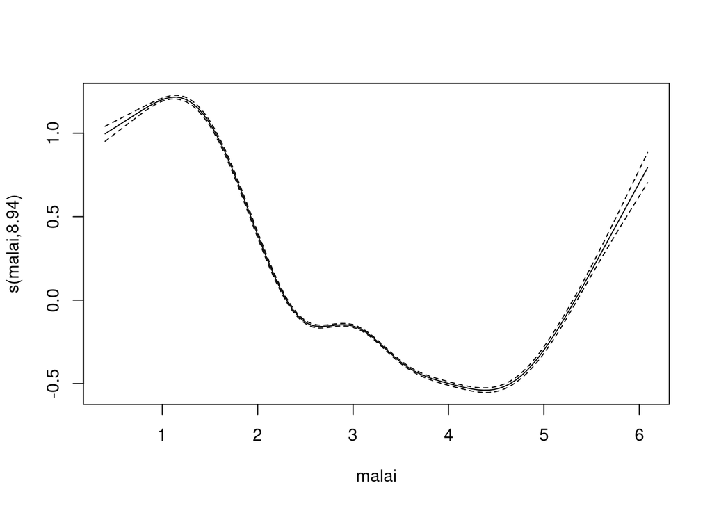

```r
b3 <- gam(min_slai_anom ~ s(malai),
  family=gaussian(),
  data=d_train)
plot(b3)
```

That looks too ‘wiggly’ to me.

Try again with a shrinkage cubic regression spline.

```r
b4 <- gam(min_slai_anom ~ s(malai, bs='cs'),
  family=gaussian(),
  data=d_train,
  method='REML') # specify restricted maximum likelihood
summary(b4)
```

```
##
## Family: gaussian
## Link function: identity
##
## Formula:
## min_slai_anom ~ s(malai, bs = "cs")
##
## Parametric coefficients:
##              Estimate Std. Error t value Pr(>|t|)
## (Intercept) -1.707910   0.001937  -881.9   <2e-16 ***
## ---
## Signif. codes:  0 '***' 0.001 '**' 0.01 '*' 0.05 '.' 0.1 ' ' 1
##
## Approximate significance of smooth terms:
##            edf Ref.df    F p-value
## s(malai) 8.947      9 9624  <2e-16 ***
## ---
## Signif. codes:  0 '***' 0.001 '**' 0.01 '*' 0.05 '.' 0.1 ' ' 1
##
## R-sq.(adj) =  0.464   Deviance explained = 46.4%
## -REML =  92831  Scale est. = 0.37488   n = 99950
```

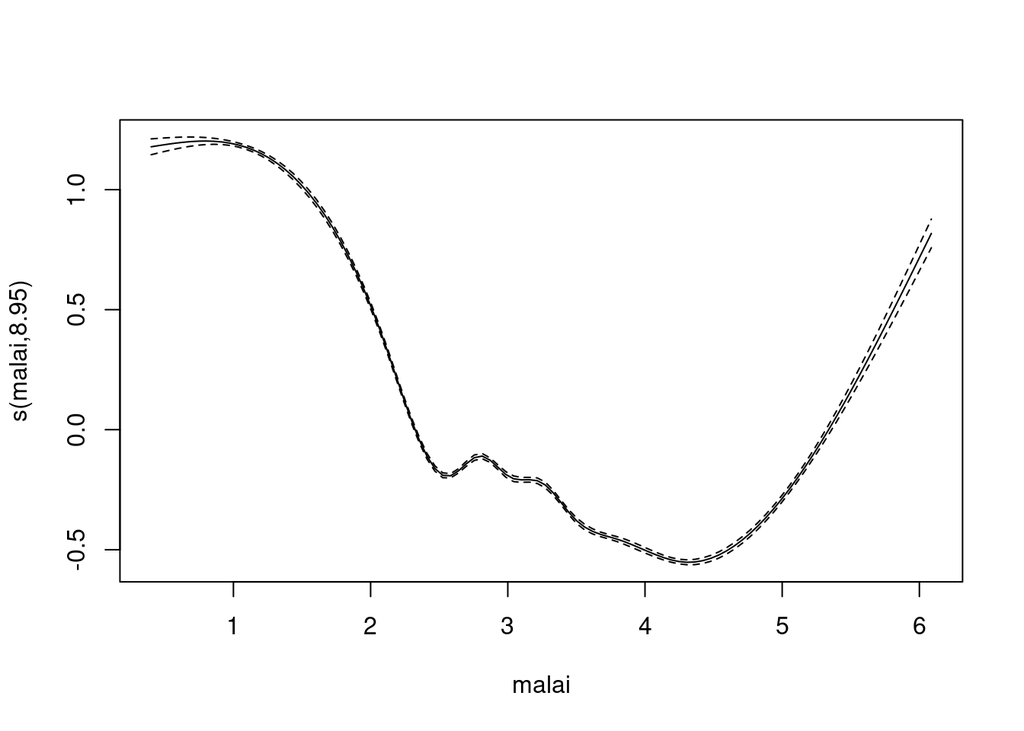

```r
plot(b4)
```

Still looks a bit ‘wiggly’ aroudn 2.5-3.5 mean annual LAI.

```r
b5 <- gam(min_slai_anom ~ s(malai, bs='cs', k=5),
  family=gaussian(),
  data=d_train)
summary(b5)
```

```
##
## Family: gaussian
## Link function: identity
##
## Formula:
## min_slai_anom ~ s(malai, bs = "cs", k = 5)
##
## Parametric coefficients:
##              Estimate Std. Error t value Pr(>|t|)
## (Intercept) -1.707910   0.001962  -870.4   <2e-16 ***
## ---
## Signif. codes:  0 '***' 0.001 '**' 0.01 '*' 0.05 '.' 0.1 ' ' 1
##
## Approximate significance of smooth terms:
##            edf Ref.df     F p-value
## s(malai) 3.999      4 20444  <2e-16 ***
## ---
## Signif. codes:  0 '***' 0.001 '**' 0.01 '*' 0.05 '.' 0.1 ' ' 1
##
## R-sq.(adj) =   0.45   Deviance explained =   45%
## GCV = 0.38488  Scale est. = 0.38486   n = 99950
```

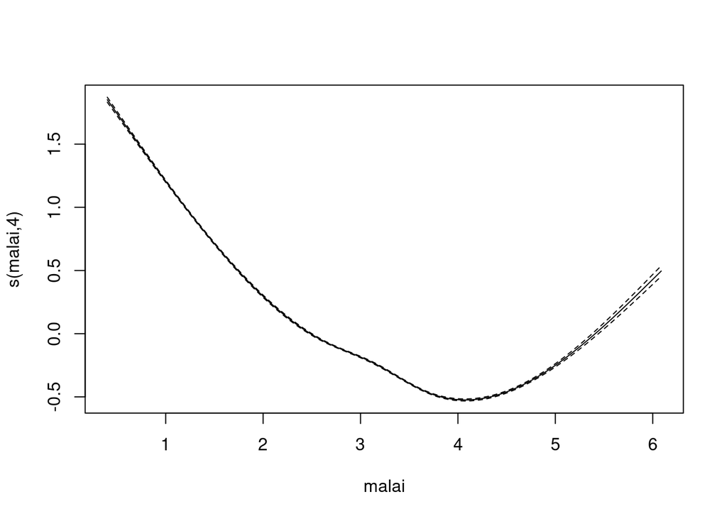

```r
plot(b5)
```

Looks better when the approximated number of knots are specified to <= 5.

```r
b6 <- gam(min_slai_anom ~ min_nbr_anom,
  family=gaussian(),
  data=d_train)
summary(b6)
```

```
##
## Family: gaussian
## Link function: identity
##
## Formula:
## min_slai_anom ~ min_nbr_anom
##
## Parametric coefficients:
##               Estimate Std. Error t value Pr(>|t|)
## (Intercept)  -0.601604   0.005578  -107.8   <2e-16 ***
## min_nbr_anom  2.710422   0.012574   215.6   <2e-16 ***
## ---
## Signif. codes:  0 '***' 0.001 '**' 0.01 '*' 0.05 '.' 0.1 ' ' 1
##
##
## R-sq.(adj) =  0.317   Deviance explained = 31.7%
## GCV = 0.47767  Scale est. = 0.47766   n = 99950
```

```r
# unpenalized
b7 <- gam(min_slai_anom ~ s(min_nbr_anom),
  family=gaussian(),
  data=d_train)
summary(b7)
```

```
##
## Family: gaussian
## Link function: identity
##
## Formula:
## min_slai_anom ~ s(min_nbr_anom)
##
## Parametric coefficients:
##              Estimate Std. Error t value Pr(>|t|)
## (Intercept) -1.707910   0.002172  -786.3   <2e-16 ***
## ---
## Signif. codes:  0 '***' 0.001 '**' 0.01 '*' 0.05 '.' 0.1 ' ' 1
##
## Approximate significance of smooth terms:
##                   edf Ref.df    F p-value
## s(min_nbr_anom) 8.612  8.954 5402  <2e-16 ***
## ---
## Signif. codes:  0 '***' 0.001 '**' 0.01 '*' 0.05 '.' 0.1 ' ' 1
##
## R-sq.(adj) =  0.326   Deviance explained = 32.6%
## GCV = 0.47158  Scale est. = 0.47154   n = 99950
```

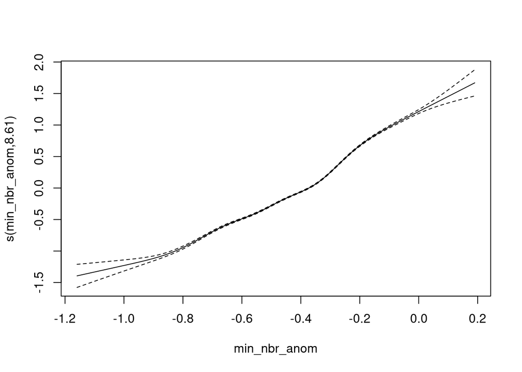

```r
plot(b7) # looks weakly nonlinear
```

That kink between -0.4 - -0.2 might be real though, but best to try a penalized smooth to see if it’s still identified.

Here the `select=TRUE` option penalizes all the smooths. The `bs='cs'` term is a form of penalized spline.

There are many smoothing function options. see: `?smooth.terms`

```r
# penalized smooth
b8 <- gam(min_slai_anom ~ s(min_nbr_anom, bs='cs'),
  family=gaussian(),
  data=d_train,
  select=TRUE,
  method='REML')
summary(b8)
```

```
##
## Family: gaussian
## Link function: identity
##
## Formula:
## min_slai_anom ~ s(min_nbr_anom, bs = "cs")
##
## Parametric coefficients:
##              Estimate Std. Error t value Pr(>|t|)
## (Intercept) -1.707910   0.002172  -786.2   <2e-16 ***
## ---
## Signif. codes:  0 '***' 0.001 '**' 0.01 '*' 0.05 '.' 0.1 ' ' 1
##
## Approximate significance of smooth terms:
##                   edf Ref.df    F p-value
## s(min_nbr_anom) 7.847      9 5371  <2e-16 ***
## ---
## Signif. codes:  0 '***' 0.001 '**' 0.01 '*' 0.05 '.' 0.1 ' ' 1
##
## R-sq.(adj) =  0.326   Deviance explained = 32.6%
## -REML = 1.0429e+05  Scale est. = 0.47164   n = 99950
```

The edf would be lower if it were more linear, so I suppose it stays as nonlinear.

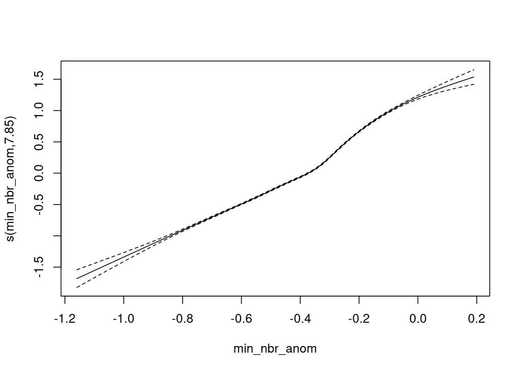

```r
plot(b8) #
```

OK, let’s stack the terms.

```r
b9 <- gam(min_slai_anom ~
    s(malai, bs='cs',k=5)+
    s(min_nbr_anom, bs='cs'),
  family=gaussian(),
  data=d_train,
  select=TRUE,
  method='REML')
summary(b9)
```

```
##
## Family: gaussian
## Link function: identity
##
## Formula:
## min_slai_anom ~ s(malai, bs = "cs", k = 5) + s(min_nbr_anom,
##     bs = "cs")
##
## Parametric coefficients:
##              Estimate Std. Error t value Pr(>|t|)
## (Intercept) -1.707910   0.001327   -1287   <2e-16 ***
## ---
## Signif. codes:  0 '***' 0.001 '**' 0.01 '*' 0.05 '.' 0.1 ' ' 1
##
## Approximate significance of smooth terms:
##                   edf Ref.df     F p-value
## s(malai)        3.997      4 41955  <2e-16 ***
## s(min_nbr_anom) 7.832      9 13172  <2e-16 ***
## ---
## Signif. codes:  0 '***' 0.001 '**' 0.01 '*' 0.05 '.' 0.1 ' ' 1
##
## R-sq.(adj) =  0.748   Deviance explained = 74.8%
## -REML =  55059  Scale est. = 0.17605   n = 99950
```

Pretty high rsq, but both terms are indicated as nonlinear (edf > 1), and important from judging by the F values.

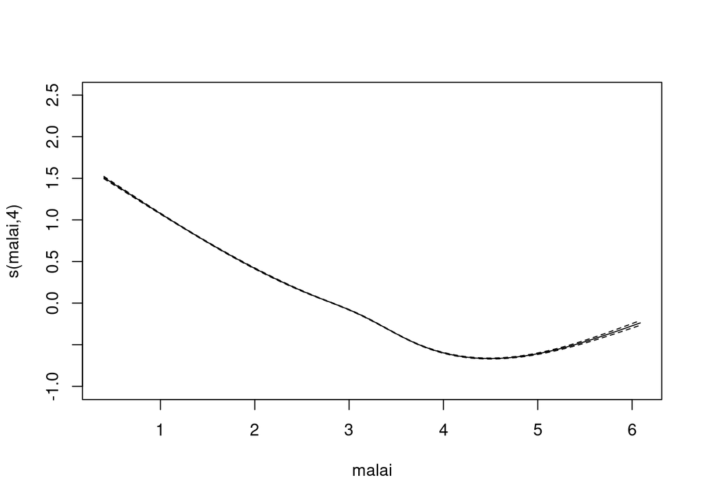

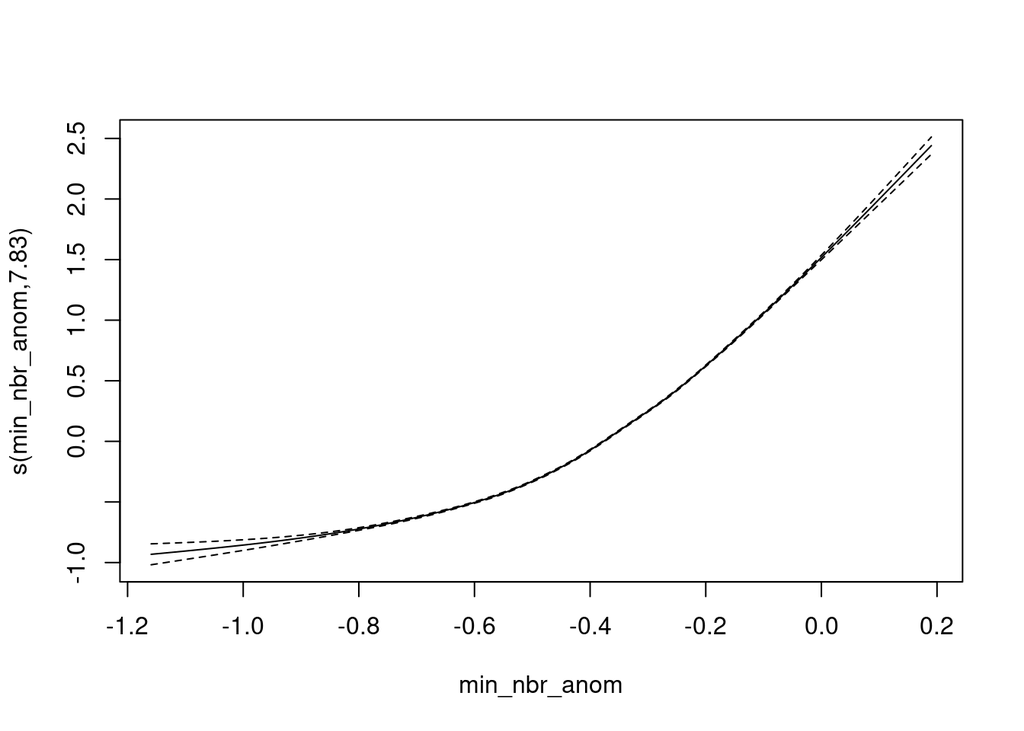

```r
plot(b9) #
```

Pretty smooth. I think this makes sense because the NBR anomaly is essentially saturating.

Here we can try a smooth interaction. I’m using a `te` function instead of `s` because the covariates are on different scales. One could use `s` if the covariates were on comparable scales. I think `te` has not been implemented for Stan yet, so `t2` is often used instead - I’m not entirely clear on the differences.

```r
b10 <- gam(min_slai_anom ~
    te(malai, min_nbr_anom, bs=c("cs","cs"), k=c(5,5)),
  family=gaussian(),
  data=d_train,
  select=TRUE,
  method='REML')
summary(b10)
```

```
##
## Family: gaussian
## Link function: identity
##
## Formula:
## min_slai_anom ~ te(malai, min_nbr_anom, bs = c("cs", "cs"), k = c(5,
##     5))
##
## Parametric coefficients:
##              Estimate Std. Error t value Pr(>|t|)
## (Intercept) -1.707910   0.001243   -1374   <2e-16 ***
## ---
## Signif. codes:  0 '***' 0.001 '**' 0.01 '*' 0.05 '.' 0.1 ' ' 1
##
## Approximate significance of smooth terms:
##                          edf Ref.df     F p-value
## te(malai,min_nbr_anom) 23.48     24 14706  <2e-16 ***
## ---
## Signif. codes:  0 '***' 0.001 '**' 0.01 '*' 0.05 '.' 0.1 ' ' 1
##
## R-sq.(adj) =  0.779   Deviance explained = 77.9%
## -REML =  48552  Scale est. = 0.15442   n = 99950
```

We can plot a heatmap of the contribution to the linear predictor using `scheme=2`.

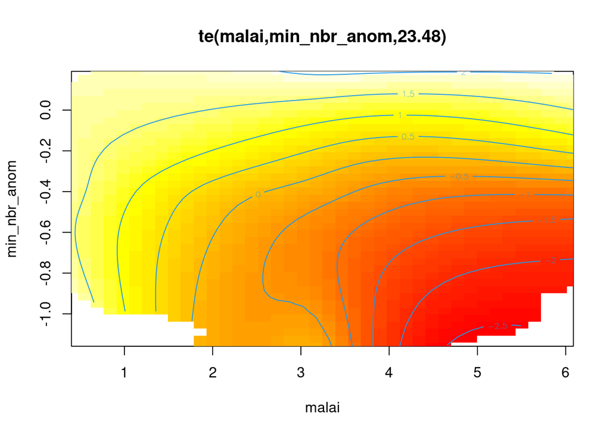

```r
plot(b10, scheme=2)
```

We judge the nonlinear interaction by the the horizontal and vertical gradients.

Try again with a random effect on the time of the burn.

```r
b11 <- gam(min_slai_anom ~
    te(malai, min_nbr_anom, bs=c("cs","cs"), k=c(5,5)) +
    s(fire_month, bs='re'),
  family=gaussian(),
  data=d_train,
  select=TRUE,
  method='REML')
summary(b11)
```

```
##
## Family: gaussian
## Link function: identity
##
## Formula:
## min_slai_anom ~ te(malai, min_nbr_anom, bs = c("cs", "cs"), k = c(5,
##     5)) + s(fire_month, bs = "re")
##
## Parametric coefficients:
##             Estimate Std. Error t value Pr(>|t|)
## (Intercept) -1.63501    0.04028  -40.59   <2e-16 ***
## ---
## Signif. codes:  0 '***' 0.001 '**' 0.01 '*' 0.05 '.' 0.1 ' ' 1
##
## Approximate significance of smooth terms:
##                          edf Ref.df       F p-value
## te(malai,min_nbr_anom) 23.51     24 1696882  <2e-16 ***
## s(fire_month)          10.81     11    1080  <2e-16 ***
## ---
## Signif. codes:  0 '***' 0.001 '**' 0.01 '*' 0.05 '.' 0.1 ' ' 1
##
## R-sq.(adj) =  0.803   Deviance explained = 80.3%
## -REML =  42970  Scale est. = 0.13802   n = 99950
```

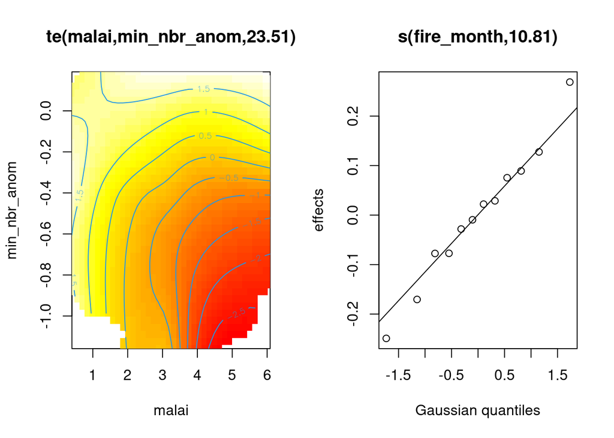

```r
plot(b11, scheme=2, pages=1)
```

Let’s compare with a linear interaction model

```r
b12 <- gam(min_slai_anom ~
    min_nbr_anom*malai+
    s(fire_month, bs='re'),
  family=gaussian(),
  data=d_train,
  select=TRUE,
  method='REML')
summary(b12)
```

```
##
## Family: gaussian
## Link function: identity
##
## Formula:
## min_slai_anom ~ min_nbr_anom * malai + s(fire_month, bs = "re")
##
## Parametric coefficients:
##                     Estimate Std. Error t value Pr(>|t|)
## (Intercept)         0.012925   0.053332   0.242  0.80851
## min_nbr_anom        0.087536   0.023367   3.746  0.00018 ***
## malai              -0.185015   0.002735 -67.652  < 2e-16 ***
## min_nbr_anom:malai  0.827697   0.007017 117.952  < 2e-16 ***
## ---
## Signif. codes:  0 '***' 0.001 '**' 0.01 '*' 0.05 '.' 0.1 ' ' 1
##
## Approximate significance of smooth terms:
##                 edf Ref.df    F p-value
## s(fire_month) 10.87     11 1216  <2e-16 ***
## ---
## Signif. codes:  0 '***' 0.001 '**' 0.01 '*' 0.05 '.' 0.1 ' ' 1
##
## R-sq.(adj) =  0.761   Deviance explained = 76.1%
## -REML =  52440  Scale est. = 0.16704   n = 99950
```

Cross validate the goodness of fit

```r
yardstick::rsq_trad_vec(truth=d_test$min_slai_anom,
  estimate=predict(b11, newdata=d_test, type='response'))
```

```
## [1] 0.8029807
```

```r
yardstick::rsq_trad_vec(truth=d_test$min_slai_anom,
  estimate=predict(b12, newdata=d_test, type='response'))
```

```
## [1] 0.760096
```

Pretty good, the R2 estimates from the models were correct.

## Simulating from a fit model

Note that you need to specify any dropped terms as NULL for the mgcv prediction to work. This is not very well documented!

```r
p_dat <- expand_grid(min_nbr_anom = seq(-1,0,length.out=10),
            malai = c(0.5,1,2,3,4,5))

p_dat <- p_dat %>%
  mutate(fire_month=NULL) %>%
  mutate(pred = predict(b11,
    newdata=.,
    newdata.guaranteed = T,
    type='response',
    exclude="s(fire_month)"))
```

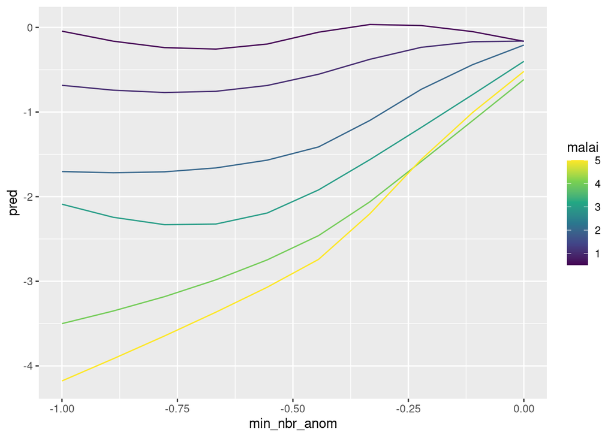

```r
p_dat %>%
  ggplot(data=., aes(min_nbr_anom,
    pred,
    color=malai, group=malai))+
  geom_line()+
  scale_color_viridis_c()
```

```r
p_dat_linear <- p_dat %>%
  select(-pred) %>%
  mutate(fire_month=NULL) %>%
  mutate(pred = predict(b12,
    newdata=.,
    newdata.guaranteed = T,
    type='response',
    exclude="s(fire_month)"))

p_compare <- bind_rows(p_dat %>% mutate(type='nonlinear'),
         p_dat_linear %>% mutate(type='linear'))
```

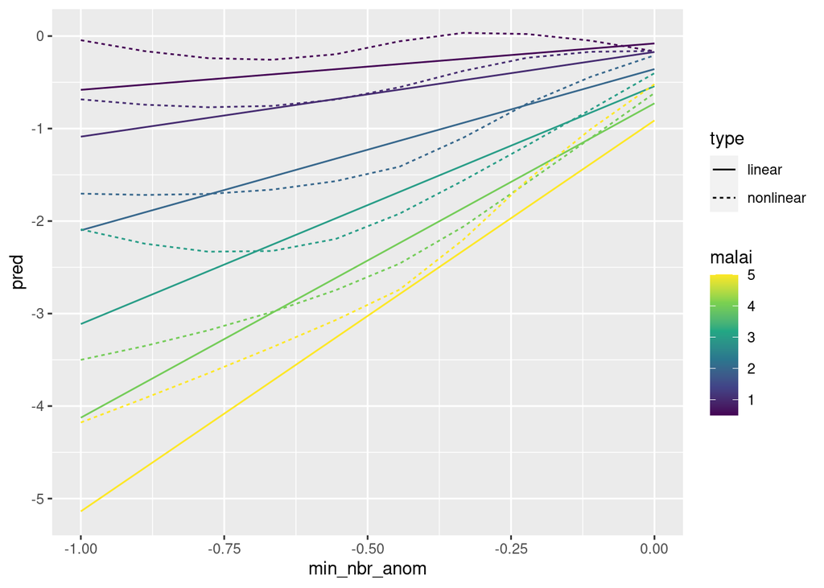

```r
p_compare %>%
  ggplot(data=.,aes(min_nbr_anom, pred,
    color=malai,
    group=paste(malai,type),
    linetype=type))+
  geom_line()+
  scale_color_viridis_c()
```